# Song Analysis Project

### There are two parts to this project:

- Part 1: Analyzing an individual song
- Part 2: What goes into making a popular song? Based on data from 2003 - 2017

```python
%%capture
# !python -m spacy download en
!pip install --no-cache-dir wordcloud
# !pip install --no-cache-dir -U folium
# !pip install --no-cache-dir textblob
# !pip install --no-cache-dir spacy
import numpy as np
import matplotlib.pyplot as plt
from ipywidgets import *
%matplotlib inline
import plotly.plotly as py
import pandas as pd
from IPython.display import HTML, display, IFrame
# import folium
# import spacy
from wordcloud import WordCloud
# from textblob import TextBlob
# import geojson
import re
import requests
from bs4 import BeautifulSoup
import string
import requests
from pprint import pprint
```

```python
bearer_token = 'Bearer ' + 'prvnibrXi_ZSvk3pzMGe8ADf_GFg2c6v5fCXVNbzNO09nX4QJA0Txk_lC-Fe-qT1' #token for Genius API
```

# Part 1: Individual Song Analysis

## Find out some facts about a song!

First, some functions to help us out with getting the song lyrics using the Genius API

```python
def clean_lyrics(lyrics):
    lyrics = re.sub(r'\[.*]', ' ', lyrics) #take out [verse 1], [chorus], [intro], [outro] etc
    lyrics = re.sub(r'\n', ' ', lyrics) #remove new lines
    lyrics = re.sub('['+string.punctuation+']', '', lyrics) #remove all punc
    lyrics = filter(None, lyrics.split(' ')) #remove empty strings
    lyrics = ' '.join(lyrics)
    return lyrics.lower()
```

```python
def clean_artist_name(name):
    name = name.replace(u'\u200b', '') #random thing attached to some artist names
    name = re.sub(r'\(.*\)', '', name)#remove parenthesis from like Kendrick Lamar (with SZA)
    return name.lower().strip()
clean_artist_name('Kendrick Lamar (with SZA)')
```

```
'kendrick lamar'
```

```python
def get_words(lyrics):
    return lyrics.split(' ')
```

```python
def num_words(lyrics):
    return len(get_words(lyrics))
```

```python
def get_unique_words(lyrics):
    return set(get_words(lyrics))
```

```python
def num_unique_words(lyrics):
    return len((get_unique_words(lyrics)))
```

```python
def count_occurences(word, lyrics):
    return lyrics.split(' ').count(word)
```

The following function will return to us the lyrics of a song in the same form as presented on the Genius website, separated by intro, verse, chorus, etc.

```python
def get_lyrics(song, artist):

    base_url = "http://api.genius.com"
    headers = {'Authorization': bearer_token}

    song_title = song
    artist_name = artist
    def get_api_path():
        if __name__ == "__main__":
            search_url = base_url + "/search"
            data = {'q': song_title}
            response = requests.get(search_url, params=data, headers=headers)
            json = response.json()
            song_info = None
        for hit in json["response"]["hits"]:
#         print(hit)
#             if clean_artist_name(hit["result"]["primary_artist"]["name"]) == clean_artist_name(artist_name):
            if clean_artist_name(artist_name) in clean_artist_name(hit["result"]["primary_artist"]["name"]):
                song_info = hit
                break
        if song_info:
            song_api_path = song_info["result"]["api_path"]
            return song_api_path
    def lyrics_from_song_api_path(song_api_path):
        if song_api_path == None:
            return np.nan
        song_url = base_url + song_api_path
        response = requests.get(song_url, headers=headers)
        json = response.json()
        path = json["response"]["song"]["path"]
        #gotta go regular html scraping... come on Genius
        page_url = "http://genius.com" + path
        page = requests.get(page_url)
        html = BeautifulSoup(page.text, "html.parser")

        [h.extract() for h in html('script')]

        lyrics = html.find('div', class_='lyrics').get_text() #updated css where the lyrics are based in HTML
        return lyrics
    return lyrics_from_song_api_path(get_api_path())
```

## Example API Response

```python
base_url = "http://api.genius.com"
headers = {'Authorization': bearer_token}

song_title = "3005"
artist_name = 'Childish gambino'

def lyrics_from_song_api_path(song_api_path):
    song_url = base_url + song_api_path
    response = requests.get(song_url, headers=headers)
    json = response.json()
    path = json["response"]["song"]["path"]

    page_url = "http://genius.com" + path
    page = requests.get(page_url)
    html = BeautifulSoup(page.text, "html.parser")
    #remove script tags that they put in the middle of the lyrics
    [h.extract() for h in html('script')]
    lyrics = html.find('div', class_='lyrics').get_text() #updated css where the lyrics are based in HTML
    return lyrics

if __name__ == "__main__":
    search_url = base_url + "/search"
    data = {'q': song_title}
    response = requests.get(search_url, params=data, headers=headers)
    json = response.json()
    song_info = None
    for hit in json["response"]["hits"]:
        print(hit)
        if clean_artist_name(artist_name) in clean_artist_name(hit["result"]["primary_artist"]["name"]):
            song_info = hit
            break
    if song_info:
        song_api_path = song_info["result"]["api_path"]
        print(lyrics_from_song_api_path(song_api_path))
```

```
{'highlights': [], 'index': 'song', 'type': 'song', 'result': {'annotation_count': 46, 'api_path': '/songs/242093', 'full_title': 'V. 3005 by\xa0Childish\xa0Gambino', 'header_image_thumbnail_url': 'https://images.genius.com/d3d7c55e142b8233760b93bf6a5bde01.300x173x1.jpg', 'header_image_url': 'https:…


[Hook]
No matter what you say or what you do
When I'm alone, I'd rather be with you
Fuck these other niggas
I'll be right by your side till 3005, hold up

[Verse 1]
Hold up, wait a minute, all good just a week ago
Crew at my house and we party every weekend so
On the radio, that's my favorite song
Make me bounce around, like I don't know, like I won't be here long
Now the thrill is gone, got no patience, cause I'm not a doctor
Girl why is you lying, girl why you Mufasa
Yeah, mi casa su casa, got it stripping like Gaza
Got so high off volcanoes, now the flow is so lava
Yeah, we spit that saliva, iPhone got message from Viber
Either the head is so hydra, or we let bygones be bygones
"My God, you pay for your friends?" I'll take that as a compliment
Got a house full of homies, why I feel so the opposite?
Incompetent ain't the half of it
Saturdays we're Young Lavish-ing
Saddest shit, is I'm bad as it
Beans they took from the cabinet (Whoa)
Sorry, I'm just scared of the future
Till 3005, I got your back, we can do this, hold up

[Hook]
No matter what you say or what you do
When I'm alone, I'd rather be with you
Fuck these other niggas
I'll be right by your side till 3005
Hold up, (hold up), hold up, (hold up)
Hold up, (hold up), hold up, (say what)
Hold up, (hold up), hold up, (hold up)
Hold up, (hold up), hold up, (hold up)...

No matter what you say or what you do
```

[output cut: 36 more lines]

```
Fuck these other niggas
I'll be right by your side till 3005
Hold up, (hold up), hold up, (hold up)
Hold up, (hold up), hold up, (hold up)
Hold up, (hold up), hold up, (hold up)
Hold up, (hold up), hold up, (hold up)...

Hold up, hold up, hold up, hold up
Hold up, hold up, hold up, hold up...

[Outro]
We did it! Yay!
Nigga, you so thirsty

[Produced by Childish Gambino, Ludwig Göransson, & Stefan Ponce]
```

```python
lyrics = get_lyrics('The Ways', 'Khalid')
cleaned = clean_lyrics(lyrics)
song_words = get_words(cleaned)
unique_song_words = get_unique_words(cleaned)
really = count_occurences('really', cleaned)
```

```python
print(lyrics);
```

```
[Pre-Chorus: Khalid]
Most of them gon' talk, I know, I know
Most of them gon' fall, I know, I know
We gon' bet it all, I know-oh-oh-oh
We gon' bet it all, I know-oh

[Chorus: Khalid]
Power girl
I really wanna know your ways
I really wanna know your ways
I really wanna know your ways
I really want a power girl
You been runnin' through my section all day
You been runnin' through my mind all day
All day, all day, all day, all day, yeah, uh

[Verse 1: Khalid]
Somethin' in the way you move
Radion beams castin' vibrant views
Pick me up when I fall down and out
Dust me off and show me all truth
Show me that I'll never fly alone
I fucked up so many times, but I still have you
Show me how you do it like that
Carryin' a brother is not easy on your back

[Pre-Chorus: Khalid]
Most of them gon' talk, I know, I know
Most of them gon' fall, I know, I know
We gon' bet it all, I know-oh-oh-oh
We gon' bet it all, I know-oh

[Chorus: Khalid]
Power girl
I really wanna know your ways
I really wanna know your ways
I really wanna know your ways (wanna know, I wanna know)
I really want a power girl
You been runnin' through my section all day
You been runnin' through my mind all day
```

[output cut: 24 more lines]

```
You been runnin' through my mind all day
All day, all day, all day, all day, yeah, uh

[Outro: Swae Lee]
Power girl out in the city, some niggas, they out in the city
Goin' nowhere, girl, you doin' in it
Goin' everywhere, girl, you don't need it
Goin' everywhere, what you doin' in it?
Power girl, why you move in the city?
Do you know, girl, girl, you know the city?
You over the city, you over the city
Power girl, yeah, she's over the city
Hourglass, yeah, she turned it over
Power girl, yeah, she's over the city
Hourglass, yeah, she turned it over
```

```python
cleaned;
```

```python
song_words;
```

```python
unique_song_words;
```

```python
really # of times the word really occurs
```

```
12
```

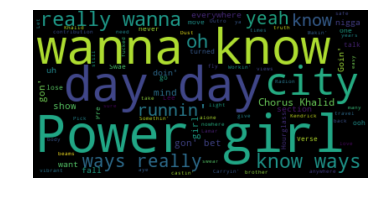

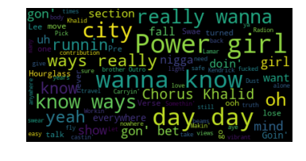

```python
wordcloud = WordCloud().generate(lyrics)

plt.imshow(wordcloud, interpolation='bilinear')
plt.axis("off")

# lower max_font_size
wordcloud = WordCloud(max_font_size=40).generate(lyrics)
plt.figure()
plt.imshow(wordcloud, interpolation="bilinear")
plt.axis("off")
plt.show()
```

## Sentiment Analysis (Microsoft Cognitive Services API)

```python
key = "6007830b0d394ade9b3977865c2435e9"
text_analytics_base_url = "https://westus.api.cognitive.microsoft.com/text/analytics/v2.0/"
sentiment_api_url = text_analytics_base_url + "sentiment"
```

```python
def get_sentiment(lyrics):
    docs = {'documents': [{'id': 0, 'language': 'en', 'text': lyrics}]}
    headers= {"Ocp-Apim-Subscription-Key": key}
    response  = requests.post(sentiment_api_url, headers=headers, json=docs)
    sentiments = response.json()
    return sentiments
```

```python
# get_sentiment(cleaned)
get_sentiment(cleaned)['documents'][0]['score']
```

```
0.5
```

# Part 2: Analysis of the top songs from 2003 - 2017

Combining 2 data sets, since the 2017 file was separate and they had a few differing columns.

```python
top_daily = pd.read_csv('regional-us-daily-apr17.csv')
top_2017 = pd.read_csv('featuresdf.csv')
top_2003_to_2016 = pd.read_csv('Now_with_Spotify_Final.csv')
top_316_cleaned = top_2003_to_2016.drop(columns=['spotify_id', 'volume_number', 'number'])
top_2017_cleaned = top_2017.drop(columns=['id']).rename(columns={"name": "title", "artists": "artist"})
top = top_316_cleaned.append(top_2017_cleaned)
```

```python
top
```

|  | acousticness | artist | danceability | duration | duration_ms | energy | instrumentalness | key | liveness | loudness | mode | speechiness | tempo | time_signature | title | valence |
| --- | --- | --- | --- | --- | --- | --- | --- | --- | --- | --- | --- | --- | --- | --- | --- | --- |
| 0 | 0.202000 | Justin Timberlake | 0.891 | 266.0 | 267267.0 | 0.714 | 0.000234 | 4.0 | 0.0521 | -6.055 | 0.0 | 0.1400 | 100.972 | 4.0 | Rock Your Body | 0.8200 |
| 1 | 0.039800 | Jennifer Lopez | 0.741 | 221.0 | 222040.0 | 0.575 | 0.127000 | 10.0 | 0.0853 | -5.416 | 0.0 | 0.0555 | 93.992 | 4.0 | I'm Glad | 0.3620 |
| 2 | 0.024100 | B2K | 0.676 | 203.0 | 205000.0 | 0.561 | 0.000000 | 3.0 | 0.0504 | -6.562 | 0.0 | 0.2160 | 89.947 | 4.0 | Girlfriend | 0.5330 |
| 3 | 0.018600 | Jay-Z | 0.691 | 229.0 | 280053.0 | 0.858 | 0.000000 | 1.0 | 0.0518 | -4.857 | 1.0 | 0.3010 | 92.773 | 4.0 | Excuse Me Miss | 0.8770 |
| 4 | 0.000290 | Ginuwine featuring Baby | 0.573 | 218.0 | 268333.0 | 0.606 | 0.000000 | 5.0 | 0.0908 | -7.114 | 0.0 | 0.2440 | 176.449 | 4.0 | Hell Yeah | 0.5780 |
| 5 | 0.043800 | Joe Budden | 0.582 | 237.0 | 251373.0 | 0.855 | 0.000000 | 6.0 | 0.1060 | -4.959 | 1.0 | 0.3310 | 104.963 | 4.0 | Pump It Up | 0.6600 |
| 6 | 0.103000 | Nas | 0.837 | 248.0 | 253720.0 | 0.885 | 0.000000 | 6.0 | 0.0666 | -3.914 | 0.0 | 0.1820 | 95.313 | 4.0 | I Can | 0.7030 |
| 7 | 0.395000 | Frankie J | 0.677 | 246.0 | 245063.0 | 0.422 | 0.000000 | 5.0 | 0.2880 | -8.443 | 0.0 | 0.0356 | 130.200 | 4.0 | Don't Wanna Try | 0.1840 |
| 8 | 0.555000 | Daniel Bedingfield | 0.682 | 242.0 | 257160.0 | 0.547 | 0.000000 | 10.0 | 0.1050 | -7.705 | 1.0 | 0.0318 | 120.000 | 4.0 | If You're Not the One | 0.2640 |
| 9 | 0.003210 | Counting Crows featuring Vanessa Carlton | 0.685 | 223.0 | 225427.0 | 0.878 | 0.000000 | 1.0 | 0.2330 | -4.346 | 1.0 | 0.0557 | 88.027 | 4.0 | Big Yellow Taxi | 0.8520 |
| 10 | 0.014500 | Robbie Williams | 0.599 | 263.0 | 263867.0 | 0.732 | 0.000467 | 5.0 | 0.1430 | -6.843 | 1.0 | 0.0262 | 97.989 | 4.0 | Feel | 0.2820 |
| 11 | 0.074700 | Stacie Orrico | 0.377 | 222.0 | 221587.0 | 0.904 | 0.000000 | 4.0 | 0.3340 | -3.634 | 0.0 | 0.3070 | 200.566 | 4.0 | Stuck | 0.5870 |
| 12 | 0.000280 | Lisa Marie Presley | 0.563 | 217.0 | 225000.0 | 0.910 | 0.000290 | 7.0 | 0.0979 | -3.819 | 1.0 | 0.0286 | 110.839 | 4.0 | Lights Out | 0.6320 |
| 13 | 0.000517 | Bowling for Soup | 0.582 | 196.0 | 197800.0 | 0.829 | 0.000000 | 2.0 | 0.2660 | -5.688 | 1.0 | 0.0465 | 130.969 | 4.0 | Girl All the Bad Guys Want | 0.8580 |
| 14 | 0.005050 | The Ataris | 0.566 | 229.0 | 230667.0 | 0.832 | 0.000000 | 8.0 | 0.1270 | -4.644 | 1.0 | 0.0603 | 175.028 | 4.0 | In This Diary | 0.8610 |
| 15 | 0.000140 | Sum 41 | 0.356 | 196.0 | 198493.0 | 0.929 | 0.006740 | 8.0 | 0.3590 | -5.464 | 0.0 | 0.0904 | 173.413 | 4.0 | The Hell Song | 0.6800 |
| 16 | 0.000281 | Chevelle | 0.468 | 250.0 | 252360.0 | 0.851 | 0.004830 | 11.0 | 0.0644 | -3.617 | 1.0 | 0.0398 | 92.079 | 4.0 | Send the Pain Below | 0.2870 |
| 17 | 0.000315 | 3 Doors Down | 0.470 | 238.0 | 239800.0 | 0.687 | 0.000007 | 4.0 | 0.1270 | -6.338 | 0.0 | 0.0276 | 87.995 | 4.0 | The Road I'm On | 0.3430 |
| 18 | 0.027900 | Godsmack | 0.692 | 225.0 | 274480.0 | 0.661 | 0.000003 | 6.0 | 0.1610 | -5.750 | 0.0 | 0.0236 | 110.161 | 4.0 | Serenity | 0.3330 |
| 19 | 0.599000 | Coldplay | 0.577 | 250.0 | 307880.0 | 0.749 | 0.011200 | 5.0 | 0.1830 | -7.215 | 0.0 | 0.0279 | 130.969 | 4.0 | Clocks | 0.2710 |
| 20 | 0.053600 | Mariah Carey | 0.701 | 233.0 | 233867.0 | 0.542 | 0.000000 | 10.0 | 0.1010 | -6.893 | 0.0 | 0.0374 | 143.595 | 4.0 | Don't Forget About Us | 0.4030 |
| 21 | 0.289000 | The Pussycat Dolls | 0.652 | 208.0 | 207507.0 | 0.551 | 0.000000 | 9.0 | 0.0778 | -6.299 | 1.0 | 0.0520 | 79.995 | 4.0 | Stickwitu | 0.3800 |
| 22 | 0.040600 | Nelly featuring Paul Wall and Ali & Gipp | 0.862 | 270.0 | 271160.0 | 0.515 | 0.000000 | 4.0 | 0.3610 | -7.305 | 0.0 | 0.2660 | 82.990 | 4.0 | Grillz | 0.8200 |
| 23 | 0.024600 | Chris Brown | 0.850 | 192.0 | 229867.0 | 0.482 | 0.000000 | 1.0 | 0.3870 | -6.684 | 0.0 | 0.1020 | 100.957 | 4.0 | Run It! | 0.2280 |
| 24 | 0.120000 | The Black Eyed Peas | 0.800 | 223.0 | 326960.0 | 0.688 | 0.000004 | 4.0 | 0.1110 | -5.987 | 1.0 | 0.2230 | 123.929 | 4.0 | My Humps | 0.6110 |
| 25 | 0.128000 | Rihanna | 0.510 | 206.0 | 208107.0 | 0.693 | 0.000000 | 8.0 | 0.0399 | -7.424 | 1.0 | 0.2590 | 96.052 | 4.0 | If It's Lovin' That You Want | 0.7030 |
| 26 | 0.064900 | Bow Wow featuring J-Kwon and Jermaine Dupri | 0.766 | 228.0 | 270147.0 | 0.606 | 0.000000 | 10.0 | 0.1620 | -5.653 | 0.0 | 0.3160 | 160.136 | 4.0 | Fresh AZIMIZ | 0.4920 |
| 27 | 0.082000 | Dem Franchize Boyz featuring Peanut and Charlay | 0.886 | 228.0 | 229813.0 | 0.620 | 0.000000 | 5.0 | 0.1000 | -5.854 | 1.0 | 0.3070 | 76.035 | 4.0 | Lean wit It, Rock wit It | 0.6130 |
| 28 | 0.038000 | Three 6 Mafia featuring Young Buck and Eightba... | 0.725 | 215.0 | 275133.0 | 0.622 | 0.013600 | 10.0 | 0.3760 | -11.223 | 1.0 | 0.0326 | 106.596 | 4.0 | Stay Fly | 0.5260 |
| 29 | 0.088000 | T-Pain | 0.722 | 185.0 | 230713.0 | 0.329 | 0.000000 | 0.0 | 0.0810 | -11.617 | 0.0 | 0.1080 | 99.991 | 4.0 | I'm Sprung | 0.1720 |
| ... | ... | ... | ... | ... | ... | ... | ... | ... | ... | ... | ... | ... | ... | ... | ... | ... |
| 70 | 0.027500 | Harry Styles | 0.516 | NaN | 340707.0 | 0.595 | 0.000000 | 5.0 | 0.1090 | -4.630 | 1.0 | 0.0313 | 119.972 | 4.0 | Sign of the Times | 0.2220 |
| 71 | 0.084700 | Travis Scott | 0.841 | NaN | 243837.0 | 0.728 | 0.000000 | 7.0 | 0.1490 | -3.370 | 1.0 | 0.0484 | 130.049 | 4.0 | goosebumps | 0.4300 |
| 72 | 0.199000 | Khalid | 0.798 | NaN | 202547.0 | 0.539 | 0.000017 | 1.0 | 0.1650 | -6.351 | 1.0 | 0.0421 | 136.949 | 4.0 | Young Dumb & Broke | 0.3940 |
| 73 | 0.124000 | Martin Garrix | 0.611 | NaN | 221904.0 | 0.644 | 0.000000 | 6.0 | 0.1240 | -7.607 | 0.0 | 0.0553 | 105.969 | 4.0 | There for You | 0.1300 |
| 74 | 0.118000 | Maroon 5 | 0.697 | NaN | 234308.0 | 0.716 | 0.000000 | 9.0 | 0.0424 | -6.288 | 0.0 | 0.1130 | 99.905 | 4.0 | Cold (feat. Future) | 0.5060 |
| 75 | 0.256000 | Marshmello | 0.520 | NaN | 180823.0 | 0.761 | 0.000005 | 4.0 | 0.1700 | -3.093 | 1.0 | 0.0853 | 141.971 | 4.0 | Silence | 0.2860 |
| 76 | 0.652000 | Sam Smith | 0.698 | NaN | 201000.0 | 0.375 | 0.000000 | 5.0 | 0.1730 | -8.279 | 1.0 | 0.0491 | 91.920 | 4.0 | Too Good At Goodbyes | 0.5340 |
| 77 | 0.003830 | Steve Aoki | 0.647 | NaN | 198774.0 | 0.932 | 0.000002 | 11.0 | 0.0574 | -3.515 | 1.0 | 0.0824 | 114.991 | 4.0 | Just Hold On | 0.3740 |
| 78 | 0.213000 | Taylor Swift | 0.773 | NaN | 211859.0 | 0.680 | 0.000016 | 9.0 | 0.1220 | -6.378 | 0.0 | 0.1410 | 128.062 | 4.0 | Look What You Made Me Do | 0.4970 |
| 79 | 0.032300 | Macklemore | 0.731 | NaN | 220454.0 | 0.794 | 0.000026 | 0.0 | 0.1120 | -5.126 | 0.0 | 0.0522 | 139.994 | 4.0 | Glorious (feat. Skylar Grey) | 0.3560 |
| 80 | 0.402000 | Hailee Steinfeld | 0.721 | NaN | 181933.0 | 0.626 | 0.000000 | 4.0 | 0.1020 | -4.200 | 1.0 | 0.1230 | 99.914 | 4.0 | Starving | 0.5580 |
| 81 | 0.400000 | CNCO | 0.761 | NaN | 222560.0 | 0.838 | 0.000000 | 4.0 | 0.1760 | -3.073 | 0.0 | 0.0502 | 93.974 | 4.0 | Reggaetón Lento (Bailemos) | 0.7100 |
| 82 | 0.137000 | AJR | 0.673 | NaN | 201160.0 | 0.637 | 0.000000 | 5.0 | 0.1840 | -4.518 | 1.0 | 0.0429 | 123.980 | 4.0 | Weak | 0.6780 |
| 83 | 0.040800 | Ariana Grande | 0.648 | NaN | 226160.0 | 0.738 | 0.000000 | 6.0 | 0.2920 | -5.883 | 0.0 | 0.2470 | 159.145 | 4.0 | Side To Side | 0.6030 |
| 84 | 0.055900 | Zion & Lennox | 0.832 | NaN | 209453.0 | 0.772 | 0.000486 | 10.0 | 0.4400 | -5.429 | 1.0 | 0.1000 | 96.016 | 4.0 | Otra Vez (feat. J Balvin) | 0.7040 |
| 85 | 0.535000 | Lauv | 0.752 | NaN | 197437.0 | 0.505 | 0.000003 | 9.0 | 0.1040 | -7.621 | 1.0 | 0.2530 | 91.970 | 4.0 | I Like Me Better | 0.4190 |
| 86 | 0.059200 | Martin Garrix | 0.490 | NaN | 195840.0 | 0.485 | 0.000000 | 4.0 | 0.3370 | -6.237 | 0.0 | 0.0406 | 133.889 | 4.0 | In the Name of Love | 0.1960 |
| 87 | 0.073600 | Major Lazer | 0.608 | NaN | 185352.0 | 0.798 | 0.000000 | 6.0 | 0.1560 | -5.092 | 0.0 | 0.0432 | 92.943 | 4.0 | Cold Water (feat. Justin Bieber & MØ) | 0.5010 |
| 88 | 0.076700 | Miley Cyrus | 0.573 | NaN | 231907.0 | 0.781 | 0.000026 | 8.0 | 0.0813 | -6.406 | 1.0 | 0.0555 | 139.934 | 4.0 | Malibu | 0.3430 |
| 89 | 0.003800 | The Vamps | 0.544 | NaN | 197640.0 | 0.809 | 0.000000 | 8.0 | 0.3230 | -5.098 | 1.0 | 0.0363 | 145.017 | 4.0 | All Night | 0.4480 |
| 90 | 0.586000 | Alok | 0.789 | NaN | 192846.0 | 0.442 | 0.003660 | 11.0 | 0.0927 | -7.844 | 1.0 | 0.0421 | 121.971 | 4.0 | Hear Me Now | 0.4500 |
| 91 | 0.158000 | Rita Ora | 0.855 | NaN | 180757.0 | 0.624 | 0.000000 | 1.0 | 0.0513 | -4.093 | 1.0 | 0.0488 | 117.959 | 4.0 | Your Song | 0.9620 |
| 92 | 0.246000 | Chris Jeday | 0.708 | NaN | 271080.0 | 0.693 | 0.000000 | 6.0 | 0.1290 | -5.516 | 1.0 | 0.1380 | 143.965 | 4.0 | Ahora Dice | 0.4270 |
| 93 | 0.004590 | Justin Bieber | 0.744 | NaN | 189467.0 | 0.739 | 0.000000 | 8.0 | 0.3060 | -5.350 | 1.0 | 0.0387 | 104.990 | 4.0 | Friends (with BloodPop®) | 0.6490 |
| 94 | 0.015100 | 21 Savage | 0.884 | NaN | 220307.0 | 0.346 | 0.000007 | 8.0 | 0.0871 | -8.228 | 0.0 | 0.3510 | 75.016 | 4.0 | Bank Account | 0.3760 |
| 95 | 0.210000 | Machine Gun Kelly | 0.675 | NaN | 239293.0 | 0.690 | 0.000000 | 2.0 | 0.2870 | -4.761 | 1.0 | 0.1320 | 137.817 | 4.0 | Bad Things (with Camila Cabello) | 0.2720 |
| 96 | 0.160000 | The Chainsmokers | 0.542 | NaN | 208053.0 | 0.859 | 0.004660 | 11.0 | 0.1370 | -5.651 | 1.0 | 0.1970 | 159.797 | 4.0 | Don't Let Me Down | 0.4030 |
| 97 | 0.463000 | Sam Hunt | 0.731 | NaN | 165387.0 | 0.469 | 0.000001 | 5.0 | 0.1030 | -7.226 | 1.0 | 0.0326 | 98.963 | 4.0 | Body Like A Back Road | 0.6310 |
| 98 | 0.105000 | Halsey | 0.658 | NaN | 214802.0 | 0.588 | 0.000001 | 6.0 | 0.1250 | -4.902 | 0.0 | 0.0367 | 110.075 | 4.0 | Now Or Never | 0.4340 |
| 99 | 0.101000 | ZAYN | 0.258 | NaN | 239000.0 | 0.437 | 0.000001 | 11.0 | 0.1060 | -6.593 | 0.0 | 0.0390 | 180.043 | 4.0 | Dusk Till Dawn - Radio Edit | 0.0967 |

1329 rows × 16 columns

```python
def convert_durationms(time):
    seconds=(time/1000)%60
    minutes=(time/(1000*60))%60
    hours=(time/(1000*60*60))%24

    return minutes
```

```python
top['duration'] = top['duration_ms'].apply(convert_durationms)
top['duration'] = top['duration'].apply(lambda x: round(x,2))
top['duration'].fillna(0, inplace=True);
```

```python
top.groupby('artist').size().sort_values(ascending=False)[:10]
```

```
artist
Britney Spears         18
Katy Perry             15
Taylor Swift           15
Nickelback             12
Bruno Mars             12
Kelly Clarkson         12
Rihanna                12
Backstreet Boys        11
The Black Eyed Peas    11
Maroon 5               11
dtype: int64
```

```python
key_letters = top[['key']].replace([0.0, 1.0, 2.0, 3.0, 4.0, 5.0, 6.0, 7.0, 8.0, 9.0, 10.0, 11.0],
                     ['C', 'C#', 'D', 'D#', 'E', 'F', 'F#', 'G', 'G#', 'A','B flat', 'B'])
```

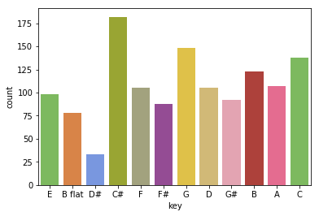

```python
colors = ['#78C850',
                    '#F08030',
                    '#6890F0',
                    '#A8B820',
                    '#A8A878',
                    '#A040A0',
                    '#F8D030',
                    '#E0C068',
                    '#EE99AC',
                    '#C03028',
                    '#F85888',

                   ]
sns.countplot(x='key', data=key_letters, palette=colors)
```

```python
top.groupby("key")['valence'].mean()
```

```
key
0.0     0.562023
1.0     0.569576
2.0     0.545910
3.0     0.527818
4.0     0.563844
5.0     0.570800
6.0     0.579095
7.0     0.549822
8.0     0.571427
9.0     0.549919
10.0    0.577551
11.0    0.575794
Name: valence, dtype: float64
```

Key doesn't seem to have a huge factor in how positive a song is, which makes some sense. It would probably be a different story if this was a different song dataset that included metal songs, classical songs, moody songs etc.

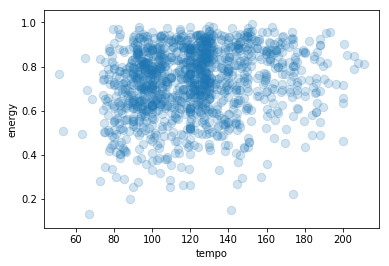

```python
plt.scatter(top['tempo'], top['energy'],s=70, alpha=0.2)
plt.xlabel('tempo')
plt.ylabel('energy')
plt.show()
```

I would think songs with a higher tempo have a better energy level, but there's a good spread from 90 - 150 BPM, with ~120 most common

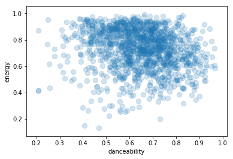

```python
plt.scatter(top['danceability'], top['energy'],s=70, alpha=0.2)
plt.xlabel('danceability')
plt.ylabel('energy')
plt.show()
```

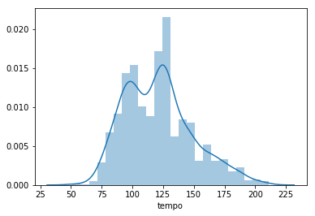

```python
sns.distplot(top['tempo'].dropna())
```

The majority of songs had a tempo of around 100 or 125 (BPM).

```python
top['liveness'].mean()
```

```
0.18578157286044719
```

```python
top['energy'].mean()
```

```
0.72962991518889753
```

```python
top['danceability'].mean()
```

```
0.6448172706245181
```

```python
top['loudness'].mean()
```

```
-5.4490254433307639
```

```python
top['speechiness'].mean()
```

```
0.088882652274479571
```

```python
top['instrumentalness'].mean()
```

```
0.0088189250732459527
```

```python
top['valence'].mean()
```

```
0.56343076329992281
```

```python
top['tempo'].mean()
```

```
121.0729036237471
```

```python
top['duration'].mean()
```

```
3.7375244544770503
```

# Conclusion

## To make a popular song, make the duration 3.7 minutes, 121 BPM, -5.4 DB, in key C#, somewhat positive, very energetic, repetitive (30% of words unique) and something people want to dance to.

# EXTRAS / SCRATCH WORK / OTHER IDEAS

```python
_
```

[output not shown]

```python
def add_num_words_column(data):
    data['lyrics'] = data['lyrics'].apply(clean_lyrics)
    data['num_words'] = data['lyrics'].apply(num_words)
    return data
top_50_wcounts = add_num_words_column(top_50)
```

```python
def add_num_unique_words(data):
    data = data.copy()
    data['num_unique_words'] = data['lyrics'].apply(num_unique_words)
    return data
top_50_wcounts = add_num_unique_words(top_50_wcounts)
```

```python
top_50_wcounts
```

|  | Position | Track Name | Artist | Streams | URL | lyrics | num_words | num_unique_words |
| --- | --- | --- | --- | --- | --- | --- | --- | --- |
| 0 | 1 | Nice For What | Drake | 2799486 | https://open.spotify.com/track/1cTZMwcBJT0Ka3U... | i wanna know who mothafuckin representin in he... | 954 | 183 |
| 1 | 2 | God's Plan | Drake | 1793626 | https://open.spotify.com/track/2XW4DbS6NddZxRP... | yeah they wishin and wishin and wishin and wis... | 347 | 134 |
| 2 | 3 | I Like It | Cardi B | 1636133 | https://open.spotify.com/track/58q2HKrzhC3ozto... | yeah baby i like it like that you gotta believ... | 766 | 296 |
| 3 | 4 | Psycho (feat. Ty Dolla $ign) | Post Malone | 1578067 | https://open.spotify.com/track/65NwOZqoXny4Jxq... | damn my ap goin psycho lil mama bad like micha... | 525 | 188 |
| 4 | 5 | Look Alive (feat. Drake) | BlocBoy JB | 1482717 | https://open.spotify.com/track/4qKcDkK6siZ7Jp1... | tay keith fuck these niggas up yeah yeah ooh y... | 594 | 198 |
| 5 | 6 | Call Out My Name | The Weeknd | 1442113 | https://open.spotify.com/track/1gm616Plq4ScqNi... | we found each other i helped you out of a brok... | 341 | 87 |
| 6 | 7 | SAD! | XXXTENTACION | 1321033 | https://open.spotify.com/track/3ee8Jmje8o58CHK... | yeah who am i someone thats afraid to let go u... | 281 | 56 |
| 7 | 8 | Plug Walk | Rich The Kid | 1213786 | https://open.spotify.com/track/6mAz8D1TmlTuef9... | ayy ayy plug walk plug walk plug plug i dont e... | 418 | 122 |
| 8 | 9 | Walk It Talk It | Migos | 1138559 | https://open.spotify.com/track/6n4U3TlzUGhdSFb... | yeah yeah deko woah hold on og parker uh walk ... | 1165 | 251 |
| 9 | 10 | Freaky Friday (feat. Chris Brown) | Lil Dicky | 1134501 | https://open.spotify.com/track/10Igtw8bSDyyFs7... | lil dicky ooh mustard on the beat ho i woke up... | 621 | 231 |
| 10 | 11 | Be Careful | Cardi B | 1062804 | https://open.spotify.com/track/2Yl4OmDby9iitgN... | yeah care for me care for me care for me uh ye... | 595 | 233 |
| 11 | 12 | JAPAN | Famous Dex | 1014014 | https://open.spotify.com/track/5PTG6rrL6EPFD9E... | you know what i’m sayin’ i just that’s just ho... | 588 | 146 |
| 12 | 13 | Love Lies (with Normani) | Khalid | 946391 | https://open.spotify.com/track/45Egmo7icyopuzJ... | sorry if its hard to catch my vibe mmm i need ... | 392 | 103 |
| 13 | 14 | Ric Flair Drip (& Metro Boomin) | Offset | 889667 | https://open.spotify.com/track/7sO5G9EABYOXQKN... | bijan 4 the 1 time metro boomin want some more... | 613 | 205 |
| 14 | 15 | The Middle | Zedd | 878313 | https://open.spotify.com/track/2ARqIya5NAuvFVH... | take a seat right over there sat on the stairs... | 345 | 87 |
| 15 | 16 | Powerglide (feat. Juicy J) | Rae Sremmurd | 876235 | https://open.spotify.com/track/2yUbCEiaolfSMlu... | yeah yeah yeah mike will madeit yeah yeah yeah... | 1001 | 332 |
| 16 | 17 | One Kiss (with Dua Lipa) | Calvin Harris | 812497 | https://open.spotify.com/track/7ef4DlsgrMEH11c... | one kiss is all it takes fallin in love with m... | 286 | 69 |
| 17 | 18 | Mine | Bazzi | 803430 | https://open.spotify.com/track/7uzmGiiJyRfuViK... | huh yeah naw i just had a lil bit too much of ... | 208 | 103 |
| 18 | 19 | All The Stars (with SZA) | Kendrick Lamar | 789164 | https://open.spotify.com/track/3GCdLUSnKSMJhs4... | love lets talk about love is it anything and e... | 474 | 147 |
| 19 | 20 | Moonlight | XXXTENTACION | 756309 | https://open.spotify.com/track/0JP9xo3adEtGSdU... | yeah spotlight uh moonlight uh nigga why you t... | 276 | 62 |
| 20 | 21 | Wasted Times | The Weeknd | 724083 | https://open.spotify.com/track/72TyiiduRmczEbD... | wasted times i spent with someone else she was... | 384 | 121 |
| 21 | 22 | rockstar | Post Malone | 706640 | https://open.spotify.com/track/2U7Hu2RaNQNRi7i... | hahahahaha tank god ayy ayy ive been fuckin ho... | 500 | 186 |
| 22 | 23 | I Fall Apart | Post Malone | 695484 | https://open.spotify.com/track/75ZvA4QfFiZvzhj... | oooh i fall apart oooh yeah mmhmm yeah she tol... | 331 | 114 |
| 23 | 24 | King's Dead (with Kendrick Lamar, Future & Jam... | Jay Rock | 679140 | https://open.spotify.com/track/51rXHuKN8Loc4sU... | miss me with that bullshit bullshit you aint r... | 807 | 253 |
| 24 | 25 | FRIENDS | Marshmello | 677735 | https://open.spotify.com/track/08bNPGLD8AhKpnn... | oooohoh oooohwoh oooohoh oooohwoh you say you ... | 425 | 112 |
| 25 | 26 | Barbie Tingz | Nicki Minaj | 675138 | https://open.spotify.com/track/2qsQ8eVDPmobZpv... | demdemdemdem demdem demdemdemdem demdemdemdem ... | 675 | 249 |
| 26 | 27 | Stir Fry | Migos | 671942 | https://open.spotify.com/track/2UVbBKQOdFAekPT... | woo woo woo woo woo woo woo woo dance with my ... | 650 | 204 |
| 27 | 28 | Meant to Be (feat. Florida Georgia Line) | Bebe Rexha | 663706 | https://open.spotify.com/track/7iDa6hUg2VgEL1o... | baby lay on back and relax kick your pretty fe... | 368 | 104 |
| 28 | 29 | Playinwitme (feat. Kehlani) | KYLE | 656964 | https://open.spotify.com/track/43cFjTTCD9Cni4a... | girl why are you playin with me girl who are y... | 407 | 111 |
| 29 | 30 | Esskeetit | Lil Pump | 654615 | https://open.spotify.com/track/44KKhCyI0BGS6Lv... | cb on the beat only wear designer esskeetit ou... | 674 | 172 |
| 30 | 31 | I Do (feat. SZA) | Cardi B | 647551 | https://open.spotify.com/track/1f5PNhkNgUpvDEe... | mmmmurda i left a nigga on read cause i felt l... | 536 | 169 |
| 31 | 32 | Bartier Cardi (feat. 21 Savage) | Cardi B | 613757 | https://open.spotify.com/track/0dIoGTQXDh1wVnh... | bardi in a rari diamonds all over my body 30 y... | 901 | 199 |
| 32 | 33 | Lemon - Drake Remix | N.E.R.D | 605595 | https://open.spotify.com/track/739vCwA3EpBSkk3... | wait wait wait a minute shout out to them peop... | 624 | 185 |
| 33 | 34 | Chun-Li | Nicki Minaj | 589944 | https://open.spotify.com/track/2gTYVoQCUh0QNUa... | ayo look like im goin for a swim dunk on em no... | 442 | 199 |
| 34 | 35 | Try Me | The Weeknd | 587958 | https://open.spotify.com/track/2poOAWEj1CStqTV... | any time is the time any time for you to get m... | 381 | 117 |
| 35 | 36 | Delicate | Taylor Swift | 576562 | https://open.spotify.com/track/6NFyWDv5Cjfwuzo... | this aint for the best my reputations never be... | 512 | 117 |
| 36 | 37 | Nevermind | Dennis Lloyd | 573599 | https://open.spotify.com/track/63SevszngYpZOwf... | alright im ready now ready now i aint gonna i ... | 399 | 49 |
| 37 | 38 | Drip (feat. Migos) | Cardi B | 571609 | https://open.spotify.com/track/2qcG0nZ6S3zZV0U... | that boy cass cardi nonstop came through dripp... | 917 | 310 |
| 38 | 39 | In My Blood | Shawn Mendes | 560217 | https://open.spotify.com/track/79jX8RM5CgPqDKd... | help me its like the walls are caving in somet... | 270 | 82 |
| 39 | 40 | 1942 | G-Eazy | 556412 | https://open.spotify.com/track/794QVQtFNy7hvtj... | i dont follow rules and they dont like that i ... | 670 | 192 |
| 40 | 41 | Let Me | ZAYN | 556041 | https://open.spotify.com/track/7Fg342AJtNsIDdw... | sweet baby our sex has meaning know this time ... | 323 | 85 |
| 41 | 42 | PICK IT UP (feat. A$AP Rocky) | Famous Dex | 544264 | https://open.spotify.com/track/0dSIrRkA4PadGll... | hey yo big bro you fucking with that ha okay c... | 628 | 275 |
| 42 | 43 | Everyday | Logic | 542176 | https://open.spotify.com/track/4EAV2cKiqKP5UPZ... | yeah ayy i work hard every motherfuckin dayaya... | 383 | 130 |
| 43 | 44 | Bodak Yellow | Cardi B | 525583 | https://open.spotify.com/track/6KBYefIoo7KydIm... | ksr its cardi ayy said im the shit they cant f... | 687 | 223 |
| 44 | 45 | Ring (feat. Kehlani) | Cardi B | 516902 | https://open.spotify.com/track/5DfWF0jqMgZDCiu... | ooh ooh ring ring ring ring you dont hit my li... | 476 | 158 |
| 45 | 46 | Red Roses (feat. Landon Cube) | Lil Skies | 516494 | https://open.spotify.com/track/3ZhTT6yjZwpPph5... | menoh and i got all the drugs in the world tha... | 723 | 252 |
| 46 | 47 | IDGAF | Dua Lipa | 493412 | https://open.spotify.com/track/76cy1WJvNGJTj78... | you call me all friendly tellin me how much yo... | 441 | 126 |
| 47 | 48 | changes | XXXTENTACION | 488096 | https://open.spotify.com/track/7AFASza1mXqntmG... | mmm baby i dont understand this youre changing... | 186 | 25 |
| 48 | 49 | XO TOUR Llif3 | Lil Uzi Vert | 487253 | https://open.spotify.com/track/7GX5flRQZVHRAGd... | are you alright im alright im quite alright an... | 490 | 166 |
| 49 | 50 | Tequila | Dan + Shay | 467357 | https://open.spotify.com/track/7Il2yWQmsqKgSkL... | i can still shut down a party i can hang with ... | 273 | 89 |

```python
print(top_50_wcounts['num_words'].mean())
print(top_50_wcounts['num_words'].median())
print(top_50_wcounts['num_words'].max())
print(top_50_wcounts['num_words'].min())
```

```
525.46
483.0
1165
186
```

```python
import seaborn as sns
```

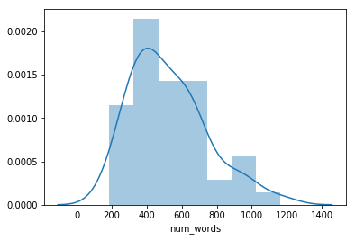

```python
sns.distplot(top_50_wcounts['num_words'])
```

```python
#Looks like most songs have less than 600 words.
```

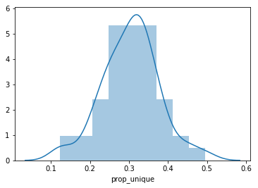

```python
top_50_wcounts['prop_unique'] = top_50_wcounts['num_unique_words'] / top_50_wcounts['num_words']
top_50_wcounts
sns.distplot(top_50_wcounts['prop_unique'])
```

```python
#Looks like in the majority of the songs, 30% of the words are unique and 70% are repeated.
```

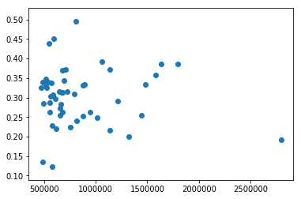

```python
plt.scatter( top_50_wcounts['Streams'],top_50_wcounts['prop_unique'])
```

```python
sentiment_api_url = text_analytics_base_url + "sentiment"
```

```python
print(sentiment_api_url)
```

```
https://westus.api.cognitive.microsoft.com/text/analytics/v2.0/sentiment
```

```python
docs = {}
doc = []
for i in range(len(top_50_wcounts)):
    doc.append({
        'id': str(i),
        'language': 'en',
        'text': top_50_wcounts['lyrics'].iloc[i]
    })
docs['documents'] = doc
docs['documents']
```

[output not shown]

[output cut: 95 more lines]

```
 {'id': '45',
  'language': 'en',
  'text': 'menoh and i got all the drugs in the world that you need we get high to pass time but bitch i aint no fiend i got money on my mind i be stacking my green shawty said she like my style i be dripping with ease please dont send me naked pictures i dont like to be teased say she got that supe…
 {'id': '46',
  'language': 'en',
  'text': 'you call me all friendly tellin me how much you miss me thats funny i guess youve heard my songs well im too busy for your business go find a girl who wants to listen cause if you think i was born yesterday you have got me wrong so i cut you off i dont need your love cause i already cried…
 {'id': '47',
  'language': 'en',
  'text': 'mmm baby i dont understand this youre changing i cant stand it my heart cant take this damage and the way i feel cant stand it mmm baby i dont understand this youre changing i cant stand it my heart cant take this damage and the way i feel cant stand it mmm baby i dont understand it girl …
 {'id': '48',
  'language': 'en',
  'text': 'are you alright im alright im quite alright and my moneys right 8… yeah countin them bands all way to the top til they be fallin over yeah yeah yeah countin them bands on my way to the top til we fallin over i dont really care if you cry on the real you shoulda never lied shoulda saw the …
 {'id': '49',
  'language': 'en',
  'text': 'i can still shut down a party i can hang with anybody i can drink whiskey and red wine champagne all night little scotch on the rocks and im fine im fine but when i taste tequila baby i still see ya cutting up the floor in a sorority tshirt the same one you wore when we were sky high in c…
```

```python
import requests
from pprint import pprint

headers   = {"Ocp-Apim-Subscription-Key": key}
response  = requests.post(sentiment_api_url, headers=headers, json=docs)
sentiments = response.json()
pprint(sentiments)
```

```
{'documents': [{'id': '0', 'score': 0.053413599729537964},
               {'id': '1', 'score': 0.06341928243637085},
               {'id': '2', 'score': 0.8636394739151001},
               {'id': '3', 'score': 0.0548989474773407},
               {'id': '4', 'score': 0.11892339587211609},
               {'id': '5', 'score': 0.144860178232193},
               {'id': '6', 'score': 0.07116040587425232},
               {'id': '7', 'score': 0.27540621161460876},
               {'id': '8', 'score': 0.9229480028152466},
               {'id': '9', 'score': 0.814321756362915},
               {'id': '10', 'score': 0.06733828783035278},
               {'id': '11', 'score': 0.8658908605575562},
               {'id': '12', 'score': 0.13550788164138794},
               {'id': '13', 'score': 0.09604263305664062},
               {'id': '14', 'score': 0.08220222592353821},
               {'id': '15', 'score': 0.21438413858413696},
               {'id': '16', 'score': 0.11633417010307312},
               {'id': '17', 'score': 0.05276036262512207},
               {'id': '18', 'score': 0.9894117116928101},
               {'id': '19', 'score': 0.10763627290725708},
               {'id': '20', 'score': 0.03302076458930969},
               {'id': '21', 'score': 0.17643919587135315},
               {'id': '22', 'score': 0.034978777170181274},
               {'id': '23', 'score': 0.06514692306518555},
               {'id': '24', 'score': 0.10447385907173157},
               {'id': '25', 'score': 0.7753500938415527},
               {'id': '26', 'score': 0.9101578593254089},
               {'id': '27', 'score': 0.7811442613601685},
               {'id': '28', 'score': 0.18974041938781738},
               {'id': '29', 'score': 0.7624856233596802},
               {'id': '30', 'score': 0.8160243034362793},
               {'id': '31', 'score': 0.01724553108215332},
               {'id': '32', 'score': 0.8104243874549866},
               {'id': '33', 'score': 0.289176344871521},
               {'id': '34', 'score': 0.782683789730072},
               {'id': '35', 'score': 0.16275599598884583},
               {'id': '36', 'score': 0.21706274151802063},
               {'id': '37', 'score': 0.5},
               {'id': '38', 'score': 0.02644065022468567},
               {'id': '39', 'score': 0.8000150322914124},
```

[output cut: 96 more lines]

```
            {'id': '43',
             'message': 'Truncated input to first 100 tokens during analysis.'},
            {'id': '44',
             'message': 'Truncated input to first 100 tokens during analysis.'},
            {'id': '45',
             'message': 'Truncated input to first 100 tokens during analysis.'},
            {'id': '46',
             'message': 'Truncated input to first 100 tokens during analysis.'},
            {'id': '47',
             'message': 'Truncated input to first 100 tokens during analysis.'},
            {'id': '48',
             'message': 'Truncated input to first 100 tokens during analysis.'},
            {'id': '49',
             'message': 'Truncated input to first 100 tokens during '
                        'analysis.'}]}
```

```python
sentiments['documents'][0]
```

```
{'id': '0', 'score': 0.053413599729537964}
```

```python
sent = []
for i in range(50):
    sent.append(sentiments['documents'][i]['score'])
sent
```

```
[0.053413599729537964,
 0.06341928243637085,
 0.8636394739151001,
 0.0548989474773407,
 0.11892339587211609,
 0.144860178232193,
 0.07116040587425232,
 0.27540621161460876,
 0.9229480028152466,
 0.814321756362915,
 0.06733828783035278,
 0.8658908605575562,
 0.13550788164138794,
 0.09604263305664062,
 0.08220222592353821,
 0.21438413858413696,
 0.11633417010307312,
 0.05276036262512207,
 0.9894117116928101,
 0.10763627290725708,
 0.03302076458930969,
 0.17643919587135315,
 0.034978777170181274,
 0.06514692306518555,
 0.10447385907173157,
 0.7753500938415527,
 0.9101578593254089,
 0.7811442613601685,
 0.18974041938781738,
 0.7624856233596802,
 0.8160243034362793,
 0.01724553108215332,
 0.8104243874549866,
 0.289176344871521,
 0.782683789730072,
 0.16275599598884583,
 0.21706274151802063,
 0.5,
 0.02644065022468567,
 0.8000150322914124,
 0.9040210247039795,
 0.8853955268859863,
 0.16679304838180542,
 0.0501236617565155,
 0.05086040496826172,
 0.14009103178977966,
 0.11589246988296509,
 0.12519261240959167,
 0.14588773250579834,
 0.897760808467865]
```

```python
top_50_wcounts['sentiment'] = sent
top_50_wcounts
```

|  | Position | Track Name | Artist | Streams | URL | lyrics | num_words | num_unique_words | prop_unique | sentiment |
| --- | --- | --- | --- | --- | --- | --- | --- | --- | --- | --- |
| 0 | 1 | Nice For What | Drake | 2799486 | https://open.spotify.com/track/1cTZMwcBJT0Ka3U... | i wanna know who mothafuckin representin in he... | 954 | 183 | 0.191824 | 0.053414 |
| 1 | 2 | God's Plan | Drake | 1793626 | https://open.spotify.com/track/2XW4DbS6NddZxRP... | yeah they wishin and wishin and wishin and wis... | 347 | 134 | 0.386167 | 0.063419 |
| 2 | 3 | I Like It | Cardi B | 1636133 | https://open.spotify.com/track/58q2HKrzhC3ozto... | yeah baby i like it like that you gotta believ... | 766 | 296 | 0.386423 | 0.863639 |
| 3 | 4 | Psycho (feat. Ty Dolla $ign) | Post Malone | 1578067 | https://open.spotify.com/track/65NwOZqoXny4Jxq... | damn my ap goin psycho lil mama bad like micha... | 525 | 188 | 0.358095 | 0.054899 |
| 4 | 5 | Look Alive (feat. Drake) | BlocBoy JB | 1482717 | https://open.spotify.com/track/4qKcDkK6siZ7Jp1... | tay keith fuck these niggas up yeah yeah ooh y... | 594 | 198 | 0.333333 | 0.118923 |
| 5 | 6 | Call Out My Name | The Weeknd | 1442113 | https://open.spotify.com/track/1gm616Plq4ScqNi... | we found each other i helped you out of a brok... | 341 | 87 | 0.255132 | 0.144860 |
| 6 | 7 | SAD! | XXXTENTACION | 1321033 | https://open.spotify.com/track/3ee8Jmje8o58CHK... | yeah who am i someone thats afraid to let go u... | 281 | 56 | 0.199288 | 0.071160 |
| 7 | 8 | Plug Walk | Rich The Kid | 1213786 | https://open.spotify.com/track/6mAz8D1TmlTuef9... | ayy ayy plug walk plug walk plug plug i dont e... | 418 | 122 | 0.291866 | 0.275406 |
| 8 | 9 | Walk It Talk It | Migos | 1138559 | https://open.spotify.com/track/6n4U3TlzUGhdSFb... | yeah yeah deko woah hold on og parker uh walk ... | 1165 | 251 | 0.215451 | 0.922948 |
| 9 | 10 | Freaky Friday (feat. Chris Brown) | Lil Dicky | 1134501 | https://open.spotify.com/track/10Igtw8bSDyyFs7... | lil dicky ooh mustard on the beat ho i woke up... | 621 | 231 | 0.371981 | 0.814322 |
| 10 | 11 | Be Careful | Cardi B | 1062804 | https://open.spotify.com/track/2Yl4OmDby9iitgN... | yeah care for me care for me care for me uh ye... | 595 | 233 | 0.391597 | 0.067338 |
| 11 | 12 | JAPAN | Famous Dex | 1014014 | https://open.spotify.com/track/5PTG6rrL6EPFD9E... | you know what i’m sayin’ i just that’s just ho... | 588 | 146 | 0.248299 | 0.865891 |
| 12 | 13 | Love Lies (with Normani) | Khalid | 946391 | https://open.spotify.com/track/45Egmo7icyopuzJ... | sorry if its hard to catch my vibe mmm i need ... | 392 | 103 | 0.262755 | 0.135508 |
| 13 | 14 | Ric Flair Drip (& Metro Boomin) | Offset | 889667 | https://open.spotify.com/track/7sO5G9EABYOXQKN... | bijan 4 the 1 time metro boomin want some more... | 613 | 205 | 0.334421 | 0.096043 |
| 14 | 15 | The Middle | Zedd | 878313 | https://open.spotify.com/track/2ARqIya5NAuvFVH... | take a seat right over there sat on the stairs... | 345 | 87 | 0.252174 | 0.082202 |
| 15 | 16 | Powerglide (feat. Juicy J) | Rae Sremmurd | 876235 | https://open.spotify.com/track/2yUbCEiaolfSMlu... | yeah yeah yeah mike will madeit yeah yeah yeah... | 1001 | 332 | 0.331668 | 0.214384 |
| 16 | 17 | One Kiss (with Dua Lipa) | Calvin Harris | 812497 | https://open.spotify.com/track/7ef4DlsgrMEH11c... | one kiss is all it takes fallin in love with m... | 286 | 69 | 0.241259 | 0.116334 |
| 17 | 18 | Mine | Bazzi | 803430 | https://open.spotify.com/track/7uzmGiiJyRfuViK... | huh yeah naw i just had a lil bit too much of ... | 208 | 103 | 0.495192 | 0.052760 |
| 18 | 19 | All The Stars (with SZA) | Kendrick Lamar | 789164 | https://open.spotify.com/track/3GCdLUSnKSMJhs4... | love lets talk about love is it anything and e... | 474 | 147 | 0.310127 | 0.989412 |
| 19 | 20 | Moonlight | XXXTENTACION | 756309 | https://open.spotify.com/track/0JP9xo3adEtGSdU... | yeah spotlight uh moonlight uh nigga why you t... | 276 | 62 | 0.224638 | 0.107636 |
| 20 | 21 | Wasted Times | The Weeknd | 724083 | https://open.spotify.com/track/72TyiiduRmczEbD... | wasted times i spent with someone else she was... | 384 | 121 | 0.315104 | 0.033021 |
| 21 | 22 | rockstar | Post Malone | 706640 | https://open.spotify.com/track/2U7Hu2RaNQNRi7i... | hahahahaha tank god ayy ayy ive been fuckin ho... | 500 | 186 | 0.372000 | 0.176439 |
| 22 | 23 | I Fall Apart | Post Malone | 695484 | https://open.spotify.com/track/75ZvA4QfFiZvzhj... | oooh i fall apart oooh yeah mmhmm yeah she tol... | 331 | 114 | 0.344411 | 0.034979 |
| 23 | 24 | King's Dead (with Kendrick Lamar, Future & Jam... | Jay Rock | 679140 | https://open.spotify.com/track/51rXHuKN8Loc4sU... | miss me with that bullshit bullshit you aint r... | 807 | 253 | 0.313507 | 0.065147 |
| 24 | 25 | FRIENDS | Marshmello | 677735 | https://open.spotify.com/track/08bNPGLD8AhKpnn... | oooohoh oooohwoh oooohoh oooohwoh you say you ... | 425 | 112 | 0.263529 | 0.104474 |
| 25 | 26 | Barbie Tingz | Nicki Minaj | 675138 | https://open.spotify.com/track/2qsQ8eVDPmobZpv... | demdemdemdem demdem demdemdemdem demdemdemdem ... | 675 | 249 | 0.368889 | 0.775350 |
| 26 | 27 | Stir Fry | Migos | 671942 | https://open.spotify.com/track/2UVbBKQOdFAekPT... | woo woo woo woo woo woo woo woo dance with my ... | 650 | 204 | 0.313846 | 0.910158 |
| 27 | 28 | Meant to Be (feat. Florida Georgia Line) | Bebe Rexha | 663706 | https://open.spotify.com/track/7iDa6hUg2VgEL1o... | baby lay on back and relax kick your pretty fe... | 368 | 104 | 0.282609 | 0.781144 |
| 28 | 29 | Playinwitme (feat. Kehlani) | KYLE | 656964 | https://open.spotify.com/track/43cFjTTCD9Cni4a... | girl why are you playin with me girl who are y... | 407 | 111 | 0.272727 | 0.189740 |
| 29 | 30 | Esskeetit | Lil Pump | 654615 | https://open.spotify.com/track/44KKhCyI0BGS6Lv... | cb on the beat only wear designer esskeetit ou... | 674 | 172 | 0.255193 | 0.762486 |
| 30 | 31 | I Do (feat. SZA) | Cardi B | 647551 | https://open.spotify.com/track/1f5PNhkNgUpvDEe... | mmmmurda i left a nigga on read cause i felt l... | 536 | 169 | 0.315299 | 0.816024 |
| 31 | 32 | Bartier Cardi (feat. 21 Savage) | Cardi B | 613757 | https://open.spotify.com/track/0dIoGTQXDh1wVnh... | bardi in a rari diamonds all over my body 30 y... | 901 | 199 | 0.220866 | 0.017246 |
| 32 | 33 | Lemon - Drake Remix | N.E.R.D | 605595 | https://open.spotify.com/track/739vCwA3EpBSkk3... | wait wait wait a minute shout out to them peop... | 624 | 185 | 0.296474 | 0.810424 |
| 33 | 34 | Chun-Li | Nicki Minaj | 589944 | https://open.spotify.com/track/2gTYVoQCUh0QNUa... | ayo look like im goin for a swim dunk on em no... | 442 | 199 | 0.450226 | 0.289176 |
| 34 | 35 | Try Me | The Weeknd | 587958 | https://open.spotify.com/track/2poOAWEj1CStqTV... | any time is the time any time for you to get m... | 381 | 117 | 0.307087 | 0.782684 |
| 35 | 36 | Delicate | Taylor Swift | 576562 | https://open.spotify.com/track/6NFyWDv5Cjfwuzo... | this aint for the best my reputations never be... | 512 | 117 | 0.228516 | 0.162756 |
| 36 | 37 | Nevermind | Dennis Lloyd | 573599 | https://open.spotify.com/track/63SevszngYpZOwf... | alright im ready now ready now i aint gonna i ... | 399 | 49 | 0.122807 | 0.217063 |
| 37 | 38 | Drip (feat. Migos) | Cardi B | 571609 | https://open.spotify.com/track/2qcG0nZ6S3zZV0U... | that boy cass cardi nonstop came through dripp... | 917 | 310 | 0.338059 | 0.500000 |
| 38 | 39 | In My Blood | Shawn Mendes | 560217 | https://open.spotify.com/track/79jX8RM5CgPqDKd... | help me its like the walls are caving in somet... | 270 | 82 | 0.303704 | 0.026441 |
| 39 | 40 | 1942 | G-Eazy | 556412 | https://open.spotify.com/track/794QVQtFNy7hvtj... | i dont follow rules and they dont like that i ... | 670 | 192 | 0.286567 | 0.800015 |
| 40 | 41 | Let Me | ZAYN | 556041 | https://open.spotify.com/track/7Fg342AJtNsIDdw... | sweet baby our sex has meaning know this time ... | 323 | 85 | 0.263158 | 0.904021 |
| 41 | 42 | PICK IT UP (feat. A$AP Rocky) | Famous Dex | 544264 | https://open.spotify.com/track/0dSIrRkA4PadGll... | hey yo big bro you fucking with that ha okay c... | 628 | 275 | 0.437898 | 0.885396 |
| 42 | 43 | Everyday | Logic | 542176 | https://open.spotify.com/track/4EAV2cKiqKP5UPZ... | yeah ayy i work hard every motherfuckin dayaya... | 383 | 130 | 0.339426 | 0.166793 |
| 43 | 44 | Bodak Yellow | Cardi B | 525583 | https://open.spotify.com/track/6KBYefIoo7KydIm... | ksr its cardi ayy said im the shit they cant f... | 687 | 223 | 0.324600 | 0.050124 |
| 44 | 45 | Ring (feat. Kehlani) | Cardi B | 516902 | https://open.spotify.com/track/5DfWF0jqMgZDCiu... | ooh ooh ring ring ring ring you dont hit my li... | 476 | 158 | 0.331933 | 0.050860 |
| 45 | 46 | Red Roses (feat. Landon Cube) | Lil Skies | 516494 | https://open.spotify.com/track/3ZhTT6yjZwpPph5... | menoh and i got all the drugs in the world tha... | 723 | 252 | 0.348548 | 0.140091 |
| 46 | 47 | IDGAF | Dua Lipa | 493412 | https://open.spotify.com/track/76cy1WJvNGJTj78... | you call me all friendly tellin me how much yo... | 441 | 126 | 0.285714 | 0.115892 |
| 47 | 48 | changes | XXXTENTACION | 488096 | https://open.spotify.com/track/7AFASza1mXqntmG... | mmm baby i dont understand this youre changing... | 186 | 25 | 0.134409 | 0.125193 |
| 48 | 49 | XO TOUR Llif3 | Lil Uzi Vert | 487253 | https://open.spotify.com/track/7GX5flRQZVHRAGd... | are you alright im alright im quite alright an... | 490 | 166 | 0.338776 | 0.145888 |
| 49 | 50 | Tequila | Dan + Shay | 467357 | https://open.spotify.com/track/7Il2yWQmsqKgSkL... | i can still shut down a party i can hang with ... | 273 | 89 | 0.326007 | 0.897761 |

```python
top_50_wcounts['sentiment'].mean() #the average sentiment is pretty low
```

```
0.3569456934928894
```

```python
top_50_wcounts['num_words'].mean()
```

```
525.46000000000004
```

```python
def sort_second(val):
    return val[1]
def top_n_words_and_counts(lyrics, n):
    result = []
    for word in get_unique_words(lyrics):
        result.append([word,count_occurences(word, lyrics)])
    result.sort(key=sort_second, reverse=True)
    return result[:n]
def top_n_words(lyrics, n):
    result = []
    words = []
    for word in get_unique_words(lyrics):
        result.append([word,count_occurences(word, lyrics)])
    result.sort(key=sort_second, reverse=True)
    for i in range(n):
        words.append(result[i][0])
    return words
```

```python
top_n_words(top_50_wcounts['lyrics'][0], 5)
```

```
['me', 'for', 'you', 'care', 'there']
```

```python
top_50_wcounts['top_5_words'] = top_50_wcounts['lyrics'].apply(top_n_words, args=(5,))
```

```python
top_50_wcounts
```

|  | Position | Track Name | Artist | Streams | URL | lyrics | num_words | num_unique_words | prop_unique | sentiment | top_5_words |
| --- | --- | --- | --- | --- | --- | --- | --- | --- | --- | --- | --- |
| 0 | 1 | Nice For What | Drake | 2799486 | https://open.spotify.com/track/1cTZMwcBJT0Ka3U... | i wanna know who mothafuckin representin in he... | 954 | 183 | 0.191824 | 0.053414 | [me, for, you, care, there] |
| 1 | 2 | God's Plan | Drake | 1793626 | https://open.spotify.com/track/2XW4DbS6NddZxRP... | yeah they wishin and wishin and wishin and wis... | 347 | 134 | 0.386167 | 0.063419 | [wishin, and, i, me, they] |
| 2 | 3 | I Like It | Cardi B | 1636133 | https://open.spotify.com/track/58q2HKrzhC3ozto... | yeah baby i like it like that you gotta believ... | 766 | 296 | 0.386423 | 0.863639 | [i, like, it, said, the] |
| 3 | 4 | Psycho (feat. Ty Dolla $ign) | Post Malone | 1578067 | https://open.spotify.com/track/65NwOZqoXny4Jxq... | damn my ap goin psycho lil mama bad like micha... | 525 | 188 | 0.358095 | 0.054899 | [the, my, like, you, with] |
| 4 | 5 | Look Alive (feat. Drake) | BlocBoy JB | 1482717 | https://open.spotify.com/track/4qKcDkK6siZ7Jp1... | tay keith fuck these niggas up yeah yeah ooh y... | 594 | 198 | 0.333333 | 0.118923 | [the, i, like, to, we] |
| 5 | 6 | Call Out My Name | The Weeknd | 1442113 | https://open.spotify.com/track/1gm616Plq4ScqNi... | we found each other i helped you out of a brok... | 341 | 87 | 0.255132 | 0.144860 | [you, my, i, on, out] |
| 6 | 7 | SAD! | XXXTENTACION | 1321033 | https://open.spotify.com/track/3ee8Jmje8o58CHK... | yeah who am i someone thats afraid to let go u... | 281 | 56 | 0.199288 | 0.071160 | [i, yeah, know, let, im] |
| 7 | 8 | Plug Walk | Rich The Kid | 1213786 | https://open.spotify.com/track/6mAz8D1TmlTuef9... | ayy ayy plug walk plug walk plug plug i dont e... | 418 | 122 | 0.291866 | 0.275406 | [plug, a, i, the, walk] |
| 8 | 9 | Walk It Talk It | Migos | 1138559 | https://open.spotify.com/track/6n4U3TlzUGhdSFb... | yeah yeah deko woah hold on og parker uh walk ... | 1165 | 251 | 0.215451 | 0.922948 | [it, walk, i, talk, like] |
| 9 | 10 | Freaky Friday (feat. Chris Brown) | Lil Dicky | 1134501 | https://open.spotify.com/track/10Igtw8bSDyyFs7... | lil dicky ooh mustard on the beat ho i woke up... | 621 | 231 | 0.371981 | 0.814322 | [i, my, the, i’m, in] |
| 10 | 11 | Be Careful | Cardi B | 1062804 | https://open.spotify.com/track/2Yl4OmDby9iitgN... | yeah care for me care for me care for me uh ye... | 595 | 233 | 0.391597 | 0.067338 | [you, me, i, a, the] |
| 11 | 12 | JAPAN | Famous Dex | 1014014 | https://open.spotify.com/track/5PTG6rrL6EPFD9E... | you know what i’m sayin’ i just that’s just ho... | 588 | 146 | 0.248299 | 0.865891 | [i, what, in, your, baby] |
| 12 | 13 | Love Lies (with Normani) | Khalid | 946391 | https://open.spotify.com/track/45Egmo7icyopuzJ... | sorry if its hard to catch my vibe mmm i need ... | 392 | 103 | 0.262755 | 0.135508 | [me, the, it, your, you] |
| 13 | 14 | Ric Flair Drip (& Metro Boomin) | Offset | 889667 | https://open.spotify.com/track/7sO5G9EABYOXQKN... | bijan 4 the 1 time metro boomin want some more... | 613 | 205 | 0.334421 | 0.096043 | [the, a, on, my, yeah] |
| 14 | 15 | The Middle | Zedd | 878313 | https://open.spotify.com/track/2ARqIya5NAuvFVH... | take a seat right over there sat on the stairs... | 345 | 87 | 0.252174 | 0.082202 | [just, the, you, middle, in] |
| 15 | 16 | Powerglide (feat. Juicy J) | Rae Sremmurd | 876235 | https://open.spotify.com/track/2yUbCEiaolfSMlu... | yeah yeah yeah mike will madeit yeah yeah yeah... | 1001 | 332 | 0.331668 | 0.214384 | [the, she, i, in, a] |
| 16 | 17 | One Kiss (with Dua Lipa) | Calvin Harris | 812497 | https://open.spotify.com/track/7ef4DlsgrMEH11c... | one kiss is all it takes fallin in love with m... | 286 | 69 | 0.241259 | 0.116334 | [one, in, you, me, the] |
| 17 | 18 | Mine | Bazzi | 803430 | https://open.spotify.com/track/7uzmGiiJyRfuViK... | huh yeah naw i just had a lil bit too much of ... | 208 | 103 | 0.495192 | 0.052760 | [you, i, just, youre, with] |
| 18 | 19 | All The Stars (with SZA) | Kendrick Lamar | 789164 | https://open.spotify.com/track/3GCdLUSnKSMJhs4... | love lets talk about love is it anything and e... | 474 | 147 | 0.310127 | 0.989412 | [the, all, you, are, stars] |
| 19 | 20 | Moonlight | XXXTENTACION | 756309 | https://open.spotify.com/track/0JP9xo3adEtGSdU... | yeah spotlight uh moonlight uh nigga why you t... | 276 | 62 | 0.224638 | 0.107636 | [moonlight, you, right, all, your] |
| 20 | 21 | Wasted Times | The Weeknd | 724083 | https://open.spotify.com/track/72TyiiduRmczEbD... | wasted times i spent with someone else she was... | 384 | 121 | 0.315104 | 0.033021 | [you, i, got, up, aint] |
| 21 | 22 | rockstar | Post Malone | 706640 | https://open.spotify.com/track/2U7Hu2RaNQNRi7i... | hahahahaha tank god ayy ayy ive been fuckin ho... | 500 | 186 | 0.372000 | 0.176439 | [a, ayy, like, and, rockstar] |
| 22 | 23 | I Fall Apart | Post Malone | 695484 | https://open.spotify.com/track/75ZvA4QfFiZvzhj... | oooh i fall apart oooh yeah mmhmm yeah she tol... | 331 | 114 | 0.344411 | 0.034979 | [i, you, my, oooh, me] |
| 23 | 24 | King's Dead (with Kendrick Lamar, Future & Jam... | Jay Rock | 679140 | https://open.spotify.com/track/51rXHuKN8Loc4sU... | miss me with that bullshit bullshit you aint r... | 807 | 253 | 0.313507 | 0.065147 | [i, it, you, your, the] |
| 24 | 25 | FRIENDS | Marshmello | 677735 | https://open.spotify.com/track/08bNPGLD8AhKpnn... | oooohoh oooohwoh oooohoh oooohwoh you say you ... | 425 | 112 | 0.263529 | 0.104474 | [it, you, i, made, havent] |
| 25 | 26 | Barbie Tingz | Nicki Minaj | 675138 | https://open.spotify.com/track/2qsQ8eVDPmobZpv... | demdemdemdem demdem demdemdemdem demdemdemdem ... | 675 | 249 | 0.368889 | 0.775350 | [the, me, bitch, i, still] |
| 26 | 27 | Stir Fry | Migos | 671942 | https://open.spotify.com/track/2UVbBKQOdFAekPT... | woo woo woo woo woo woo woo woo dance with my ... | 650 | 204 | 0.313846 | 0.910158 | [the, in, it, like, whip] |
| 27 | 28 | Meant to Be (feat. Florida Georgia Line) | Bebe Rexha | 663706 | https://open.spotify.com/track/7iDa6hUg2VgEL1o... | baby lay on back and relax kick your pretty fe... | 368 | 104 | 0.282609 | 0.781144 | [be, to, itll, its, meant] |
| 28 | 29 | Playinwitme (feat. Kehlani) | KYLE | 656964 | https://open.spotify.com/track/43cFjTTCD9Cni4a... | girl why are you playin with me girl who are y... | 407 | 111 | 0.272727 | 0.189740 | [you, me, with, that, are] |
| 29 | 30 | Esskeetit | Lil Pump | 654615 | https://open.spotify.com/track/44KKhCyI0BGS6Lv... | cb on the beat only wear designer esskeetit ou... | 674 | 172 | 0.255193 | 0.762486 | [on, a, ouu, esskeetit, x] |
| 30 | 31 | I Do (feat. SZA) | Cardi B | 647551 | https://open.spotify.com/track/1f5PNhkNgUpvDEe... | mmmmurda i left a nigga on read cause i felt l... | 536 | 169 | 0.315299 | 0.816024 | [i, do, like, what, a] |
| 31 | 32 | Bartier Cardi (feat. 21 Savage) | Cardi B | 613757 | https://open.spotify.com/track/0dIoGTQXDh1wVnh... | bardi in a rari diamonds all over my body 30 y... | 901 | 199 | 0.220866 | 0.017246 | [cardi, the, on, bitch, a] |
| 32 | 33 | Lemon - Drake Remix | N.E.R.D | 605595 | https://open.spotify.com/track/739vCwA3EpBSkk3... | wait wait wait a minute shout out to them peop... | 624 | 185 | 0.296474 | 0.810424 | [the, bath, i, wait, a] |
| 33 | 34 | Chun-Li | Nicki Minaj | 589944 | https://open.spotify.com/track/2gTYVoQCUh0QNUa... | ayo look like im goin for a swim dunk on em no... | 442 | 199 | 0.450226 | 0.289176 | [the, on, i, been, bitch] |
| 34 | 35 | Try Me | The Weeknd | 587958 | https://open.spotify.com/track/2poOAWEj1CStqTV... | any time is the time any time for you to get m... | 381 | 117 | 0.307087 | 0.782684 | [me, you, try, the, i] |
| 35 | 36 | Delicate | Taylor Swift | 576562 | https://open.spotify.com/track/6NFyWDv5Cjfwuzo... | this aint for the best my reputations never be... | 512 | 117 | 0.228516 | 0.162756 | [it, isnt, i, that, you] |
| 36 | 37 | Nevermind | Dennis Lloyd | 573599 | https://open.spotify.com/track/63SevszngYpZOwf... | alright im ready now ready now i aint gonna i ... | 399 | 49 | 0.122807 | 0.217063 | [nevermind, and, it, your, i] |
| 37 | 38 | Drip (feat. Migos) | Cardi B | 571609 | https://open.spotify.com/track/2qcG0nZ6S3zZV0U... | that boy cass cardi nonstop came through dripp... | 917 | 310 | 0.338059 | 0.500000 | [drip, drippin, through, came, a] |
| 38 | 39 | In My Blood | Shawn Mendes | 560217 | https://open.spotify.com/track/79jX8RM5CgPqDKd... | help me its like the walls are caving in somet... | 270 | 82 | 0.303704 | 0.026441 | [i, in, my, it, like] |
| 39 | 40 | 1942 | G-Eazy | 556412 | https://open.spotify.com/track/794QVQtFNy7hvtj... | i dont follow rules and they dont like that i ... | 670 | 192 | 0.286567 | 0.800015 | [that, im, my, dont, on] |
| 40 | 41 | Let Me | ZAYN | 556041 | https://open.spotify.com/track/7Fg342AJtNsIDdw... | sweet baby our sex has meaning know this time ... | 323 | 85 | 0.263158 | 0.904021 | [the, of, for, rest, you] |
| 41 | 42 | PICK IT UP (feat. A$AP Rocky) | Famous Dex | 544264 | https://open.spotify.com/track/0dSIrRkA4PadGll... | hey yo big bro you fucking with that ha okay c... | 628 | 275 | 0.437898 | 0.885396 | [i, the, my, it, up] |
| 42 | 43 | Everyday | Logic | 542176 | https://open.spotify.com/track/4EAV2cKiqKP5UPZ... | yeah ayy i work hard every motherfuckin dayaya... | 383 | 130 | 0.339426 | 0.166793 | [i, the, my, and, yeah] |
| 43 | 44 | Bodak Yellow | Cardi B | 525583 | https://open.spotify.com/track/6KBYefIoo7KydIm... | ksr its cardi ayy said im the shit they cant f... | 687 | 223 | 0.324600 | 0.050124 | [i, you, a, dont, the] |
| 44 | 45 | Ring (feat. Kehlani) | Cardi B | 516902 | https://open.spotify.com/track/5DfWF0jqMgZDCiu... | ooh ooh ring ring ring ring you dont hit my li... | 476 | 158 | 0.331933 | 0.050860 | [ring, you, i, it, dont] |
| 45 | 46 | Red Roses (feat. Landon Cube) | Lil Skies | 516494 | https://open.spotify.com/track/3ZhTT6yjZwpPph5... | menoh and i got all the drugs in the world tha... | 723 | 252 | 0.348548 | 0.140091 | [i, you, my, she, a] |
| 46 | 47 | IDGAF | Dua Lipa | 493412 | https://open.spotify.com/track/76cy1WJvNGJTj78... | you call me all friendly tellin me how much yo... | 441 | 126 | 0.285714 | 0.115892 | [you, i, your, dont, so] |
| 47 | 48 | changes | XXXTENTACION | 488096 | https://open.spotify.com/track/7AFASza1mXqntmG... | mmm baby i dont understand this youre changing... | 186 | 25 | 0.134409 | 0.125193 | [it, i, cant, youre, this] |
| 48 | 49 | XO TOUR Llif3 | Lil Uzi Vert | 487253 | https://open.spotify.com/track/7GX5flRQZVHRAGd... | are you alright im alright im quite alright an... | 490 | 166 | 0.338776 | 0.145888 | [the, my, all, me, to] |
| 49 | 50 | Tequila | Dan + Shay | 467357 | https://open.spotify.com/track/7Il2yWQmsqKgSkL... | i can still shut down a party i can hang with ... | 273 | 89 | 0.326007 | 0.897761 | [i, when, tequila, the, taste] |